# Analyse comparative : L’affaire Quentin Deranque

Mémoire Sciences Po Lille - Corpus 2026

Léo-Pol Karim

2026-04-28

# 1 Paramétrage

```r
# ─── Séquences thématiques ────────────────────────────────────────────────
# Séquence 1 : Affaire Quentin Deranque
SEQ1_NOM      <- "Affaire Deranque"
SEQ1_KEYWORDS <- c("quentin", "deranque")

# ─── Paramètres d'extraction France 2 ────────────────────────────────────
# Taille de la fenêtre (en mots) autour de chaque occurrence d'un mot-clé
# dans les JT complets. 150 mots ≈ 1 minute de parole.
WINDOW_SIZE <- 150

# ─── Date de début du corpus principal ───────────────────────────────────
DATE_DEBUT <- as.Date("2026-02-08")
```

# 2 Cadre méthodologique

Cette analyse repose sur quatre opérations complémentaires, toutes normalisées en **occurrences pour 1 000 mots** afin de rendre comparables des documents de volumes très différents.

| Dimension | Opération | Outil |
| --- | --- | --- |
| **Pathos** | Densité émotionnelle (FEEL) | Dictionnaire lexical |
| **Logos** | Connecteurs logiques + densité de chiffres | Regex |
| **Cadrage** | Champs lexicaux thématiques | Dictionnaires maison |
| **Sources** | Verbes de citation + noms d’acteurs | Regex |

> **Limite principale assumée** : les transcriptions sont automatiques (YouTube/Whisper), ce qui génère des artefacts (mots mal découpés, ponctuation absente, homophones). Un nettoyage ciblé est appliqué, mais une validation manuelle sur sous-échantillon reste recommandée.

> **Limite structurelle** : chaque ligne France 2 = un JT complet (≈ 30–60 min, 15+ sujets). Une extraction par fenêtre contextuelle est appliquée avant toute comparaison thématique pour éviter la dilution des indicateurs dans du hors-sujet.

# 3 Chargement & Nettoyage des données

```r
# ─── Fonction de nettoyage Whisper ───────────────────────────────────────
clean_whisper <- function(text) {
  text |>
    str_to_lower() |>
    # Suppression des artefacts de sous-titrage automatique
    str_replace_all("\\[.*?\\]", " ") |>          # [musique], [applaudissements]
    str_replace_all("\\(.*?\\)", " ") |>           # (inaudible)
    str_replace_all("(?<=[a-z])(?=[A-Z])", " ") |> # CamelCase collé
    # On garde les lettres, chiffres, espaces, tirets et ':' (pour les heures)
    str_replace_all("[^a-zàâäéèêëîïôùûüç0-9\\s'\\-:]", " ") |>
    str_replace_all("\\s{2,}", " ") |>
    str_trim()
}

# ─── Fonction de comptage du Logos (Chiffres significatifs) ──────────────
count_logos_stats <- function(text) {
  if (is.na(text)) return(0)
  t <- str_to_lower(text)

  # 1. Exclusion des noms de chaînes (france 2, france 3, etc.)
  t <- str_replace_all(t, "france\\s*\\d+", " ")

  # 2. Exclusion des heures (20h, 13h30, 20:30, 8 h 30)
  t <- str_replace_all(t, "\\d+\\s*h\\s*\\d*", " ")
  t <- str_replace_all(t, "\\d+:\\d+", " ")

  # 3. Exclusion des dates/années (19xx ou 20xx)
  t <- str_replace_all(t, "\\b(19|20)\\d{2}\\b", " ")

  # 4. Comptage des séquences de chiffres restantes
  return(str_count(t, "\\d+"))
}

# ─── Chargement Blast ─────────────────────────────────────────────────────
blast <- read_csv("resultats_blast_final.csv") |>
  mutate(
    id           = as.character(id),
    source       = "Blast",
    slot         = "Web",
    date         = as.Date(date_publi),
    transcription = clean_whisper(transcription)
  ) |>
  filter(date >= DATE_DEBUT, !is.na(transcription)) |>
  select(id, titre, date, transcription, source, slot)

# ─── Chargement Le Média ──────────────────────────────────────────────────
lemedia <- read_csv("resultats_lemedia_final.csv") |>
  mutate(
    id           = as.character(id),
    source       = "Le Média",
    slot         = "Web",
    date         = as.Date(parse_date_time(date_publi, orders = c("Ymd", "mdY", "dmy"))),
    transcription = clean_whisper(transcription)
  ) |>
  filter(date >= DATE_DEBUT, !is.na(transcription)) |>
  select(id, titre, date, transcription, source, slot)

# ─── Chargement France 2 ─────────────────────────────────────────────────
# Chaque ligne = un JT complet → extraction du slot depuis le titre
jt <- read_csv("jt_database.csv") |>
  mutate(
    id           = as.character(id),
    source       = "France 2",
    date         = as.Date(date),
    transcription = clean_whisper(transcription),
    slot         = case_when(
      str_detect(titre, "08|8h")  ~ "JT 8h",
      str_detect(titre, "13|13h") ~ "JT 13h",
      str_detect(titre, "20|20h") ~ "JT 20h",
      TRUE                         ~ "JT Autre"
    )
  ) |>
  filter(date >= DATE_DEBUT, !is.na(transcription)) |>
  select(id, titre, date, transcription, source, slot)

# ─── Corpus complet ───────────────────────────────────────────────────────
corpus_full <- bind_rows(blast, lemedia, jt) |>
  mutate(
    word_count = str_count(transcription, "\\S+"),
    source     = factor(source, levels = c("France 2", "Blast", "Le Média"))
  ) |>
  # Filtrage des documents trop courts (artefacts, transcriptions vides)
  filter(word_count >= 100)

cat("─── Corpus chargé ───────────────────────────────────────\n")
```

```
## ─── Corpus chargé ───────────────────────────────────────
```

```r
cat("Documents :", nrow(corpus_full), "\n\n")
```

```
## Documents : 363
```

```r
print(corpus_full |> count(source, slot) |> arrange(source))
```

```
## # A tibble: 5 × 3
##   source   slot       n
##   <fct>    <chr>  <int>
## 1 France 2 JT 13h    56
## 2 France 2 JT 20h    52
## 3 France 2 JT 8h     55
## 4 Blast    Web       81
## 5 Le Média Web      119
```

```r
# ─── Dictionnaire FEEL ───────────────────────────────────────────────────
# Structure : id / word / polarity / joy / fear / sadness / anger /
#             surprise / disgust
feel <- read_delim("FEEL.csv", delim = ";") |>
  select(-id) |>
  mutate(word = str_to_lower(word))

cat("FEEL : ", nrow(feel), "entrées\n")
```

```
## FEEL :  14127 entrées
```

# 4 Description du corpus - Asymétrie structurelle

> Cette section est analytiquement importante : elle documente pourquoi France 2 ne peut pas être comparée brute à Blast/Le Média, et justifie le recours à la normalisation par densité et à l’extraction par fenêtre.

```
## $`1`
```

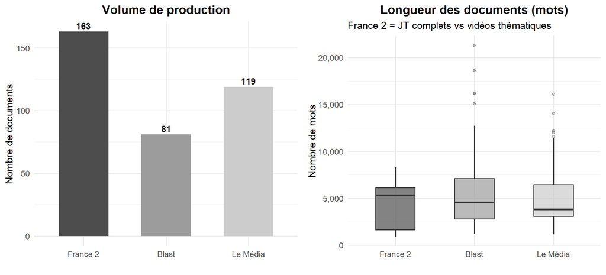

```
##
## $`2`
```

[figure not shown]

```
##
## attr(,"class")
## [1] "list"      "ggarrange"
```

```r
# ─── Volume de production par source ──────────────────────────────────────
p1 <- corpus_full |>
  count(source) |>
  ggplot(aes(x = source, y = n, fill = source)) +
  geom_bar(stat = "identity", width = 0.6) +
  geom_text(aes(label = n), vjust = -0.4, size = 4, fontface = "bold") +
  scale_fill_grey(start = 0.3, end = 0.8) +
  theme_minimal(base_size = 13) +
  theme(legend.position = "none",
        plot.title = element_text(face = "bold", hjust = 0.5)) +
  labs(title = "Volume de production", y = "Nombre de documents", x = "")


p2 <- corpus_full |>
  ggplot(aes(x = source, y = word_count, fill = source)) +
  geom_boxplot(alpha = 0.7, outlier.shape = 21, outlier.size = 1.5,
               width = 0.5) +
  scale_fill_grey(start = 0.3, end = 0.8) +
  scale_y_continuous(labels = comma) +
  theme_minimal(base_size = 13) +
  theme(legend.position = "none",
        plot.title = element_text(face = "bold", hjust = 0.5)) +
  labs(title = "Longueur des documents (mots)",
       subtitle = "France 2 = JT complets vs vidéos thématiques",
       y = "Nombre de mots", x = "")

ggarrange(p1, p2, ncol = 2,
          top = text_grob(
            "Asymétrie structurelle du corpus - justification de la normalisation",
            face = "bold", size = 13))
```

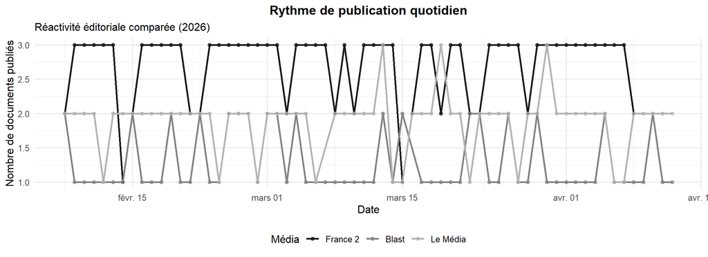

```r
# Rythme de publication par source
corpus_full |>
  count(source, date) |>
  ggplot(aes(x = date, y = n, color = source, group = source)) +
  geom_line(linewidth = 0.9) +
  geom_point(size = 1.5, alpha = 0.7) +
  scale_color_grey(start = 0.1, end = 0.7) +
  theme_minimal(base_size = 12) +
  theme(plot.title = element_text(face = "bold", hjust = 0.5),
        legend.position = "bottom") +
  labs(title = "Rythme de publication quotidien",
       subtitle = "Réactivité éditoriale comparée (2026)",
       x = "Date", y = "Nombre de documents publiés", color = "Média")
```

```r
# Tableau statistique descriptif du corpus
corpus_full |>
  group_by(source) |>
  summarise(
    `N documents`     = n(),
    `Mots total`      = sum(word_count),
    `Moy. mots/doc`   = round(mean(word_count)),
    `Médiane mots`    = round(median(word_count)),
    `Min mots`        = min(word_count),
    `Max mots`        = max(word_count)
  ) |>
  kable(caption = "Statistiques descriptives du corpus",
        format.args = list(big.mark = " ")) |>
  kable_styling(bootstrap_options = c("striped", "hover"), full_width = FALSE)
```

Statistiques descriptives du corpus

| source | N documents | Mots total | Moy. mots/doc | Médiane mots | Min mots | Max mots |
| --- | --- | --- | --- | --- | --- | --- |
| France 2 | 163 | 727 868 | 4 465 | 5 302 | 909 | 8 305 |
| Blast | 81 | 452 028 | 5 581 | 4 548 | 1 222 | 21 292 |
| Le Média | 119 | 611 563 | 5 139 | 3 826 | 1 154 | 16 077 |

# 5 Extraction thématique - Séquences d’actualité

> **Principe** : on isole les documents (et, pour France 2, les passages) qui traitent effectivement chaque séquence. C’est la condition sine qua non pour comparer des contenus thématiquement équivalents.

```r
extract_thematic_text <- function(text, keywords, window = WINDOW_SIZE,
                                  is_full_jt = FALSE) {
  kw_pattern <- paste0("\\b(", paste(keywords, collapse = "|"), ")\\b")

  if (!str_detect(text, kw_pattern)) return(NA_character_)

  if (!is_full_jt) return(text)  # Blast/Le Média : texte entier

  # France 2 : extraction par fenêtre
  words   <- str_split(text, "\\s+")[[1]]
  matches <- which(str_detect(str_to_lower(words), kw_pattern))

  windows <- map_chr(matches, function(pos) {
    start <- max(1, pos - window)
    end   <- min(length(words), pos + window)
    paste(words[start:end], collapse = " ")
  })

  paste(unique(windows), collapse = " [---] ")
}


corpus_seq1 <- corpus_full |>
  mutate(
    is_jt   = (source == "France 2"),
    text_seq = map2_chr(
      transcription, is_jt,
      ~ extract_thematic_text(.x, SEQ1_KEYWORDS, is_full_jt = .y)
    )
  ) |>
  filter(!is.na(text_seq)) |>
  mutate(
    word_count_seq = str_count(text_seq, "\\S+"),
    sequence       = SEQ1_NOM
  )

cat("=== Séquence 1 :", SEQ1_NOM, "===\n")
```

```
## === Séquence 1 : Affaire Deranque ===
```

```r
cat("Documents retenus :", nrow(corpus_seq1), "\n")
```

```
## Documents retenus : 76
```

```r
print(corpus_seq1 |> count(source, sort = TRUE))
```

```
## # A tibble: 3 × 2
##   source       n
##   <fct>    <int>
## 1 France 2    33
## 2 Le Média    28
## 3 Blast       15
```

```r
cat("\n── Mots extraits par source ──\n")
```

```
##
## ── Mots extraits par source ──
```

```r
print(corpus_seq1 |>
  group_by(source) |>
  summarise(mots_totaux = sum(word_count_seq), moy_par_doc = round(mean(word_count_seq))))
```

```
## # A tibble: 3 × 3
##   source   mots_totaux moy_par_doc
##   <fct>          <int>       <dbl>
## 1 France 2       36388        1103
## 2 Blast          70132        4675
## 3 Le Média      120978        4321
```

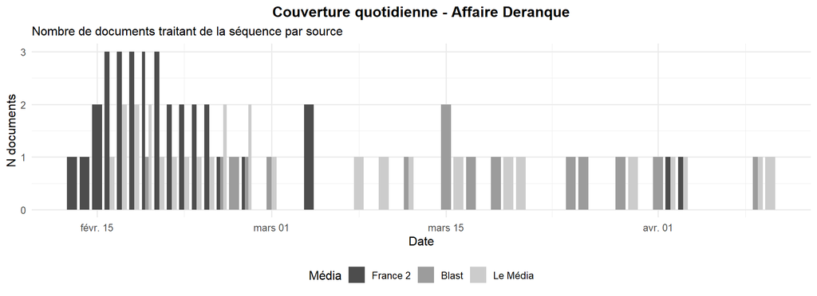

```r
# ─── Visualisation de la couverture de la séquence ────────────────────────
corpus_seq1 |>
  count(source, date) |>
  ggplot(aes(x = date, y = n, fill = source)) +
  geom_bar(stat = "identity", position = "dodge", width = 0.8) +
  scale_fill_grey(start = 0.3, end = 0.8) +
  theme_minimal(base_size = 12) +
  theme(plot.title = element_text(face = "bold", hjust = 0.5),
        legend.position = "bottom") +
  labs(
    title    = paste("Couverture quotidienne -", SEQ1_NOM),
    subtitle = "Nombre de documents traitant de la séquence par source",
    x = "Date", y = "N documents", fill = "Média"
  )
```

# 6 Analyse du Pathos - Densité émotionnelle (FEEL)

```r
# ─── Tokenisation sur les textes filtrés ──────────────────────────────────
tokens_seq1 <- corpus_seq1 |>
  select(id, source, date, slot, sequence, word_count_seq, text_seq) |>
  unnest_tokens(word, text_seq) |>
  filter(str_length(word) > 2) |>
  inner_join(feel, by = "word")

cat("Tokens émotionnels (séquence 1) :", nrow(tokens_seq1), "\n")
```

```
## Tokens émotionnels (séquence 1) : 36648
```

## 6.1 Densité émotionnelle globale

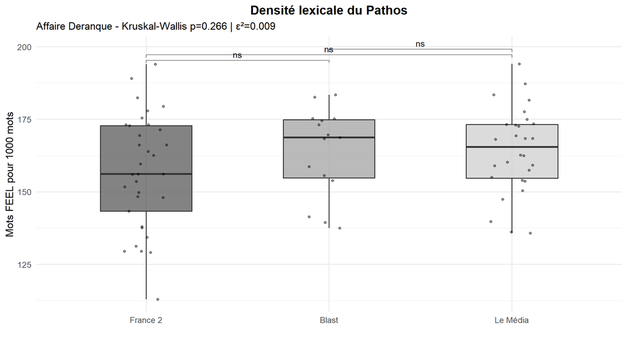

```r
# ─── Calcul de la densité émotionnelle par document ───────────────────────
intensity_seq1 <- corpus_seq1 |>
  left_join(
    tokens_seq1 |> count(id, name = "emot_count"),
    by = "id"
  ) |>
  mutate(
    emot_count   = replace_na(emot_count, 0),
    emot_density = emot_count / word_count_seq * 1000
  )

# ─── Tests statistiques ───────────────────────────────────────────────────
kw_emot  <- intensity_seq1 |> kruskal_test(emot_density ~ source)
pw_emot  <- intensity_seq1 |>
  wilcox_test(emot_density ~ source, p.adjust.method = "bonferroni") |>
  add_significance() |> add_xy_position(x = "source")
es_emot  <- intensity_seq1 |> kruskal_effsize(emot_density ~ source)

# ─── Visualisation ───────────────────────────────────────────────────────
ggplot(intensity_seq1, aes(x = source, y = emot_density, fill = source)) +
  geom_boxplot(alpha = 0.7, outlier.shape = 21, outlier.size = 1.5, width = 0.5) +
  geom_jitter(width = 0.12, alpha = 0.4, size = 1.2) +
  stat_pvalue_manual(pw_emot, label = "p.adj.signif", tip.length = 0.01) +
  scale_fill_grey(start = 0.3, end = 0.8) +
  theme_minimal(base_size = 13) +
  theme(legend.position = "none",
        plot.title = element_text(face = "bold", hjust = 0.5)) +
  labs(
    title    = "Densité lexicale du Pathos",
    subtitle = paste0(
      SEQ1_NOM, " - Kruskal-Wallis p=", round(kw_emot$p, 4),
      " | ε²=", round(es_emot$effsize, 3)
    ),
    y = "Mots FEEL pour 1000 mots", x = ""
  )
```

## 6.2 Profils émotionnels comparés

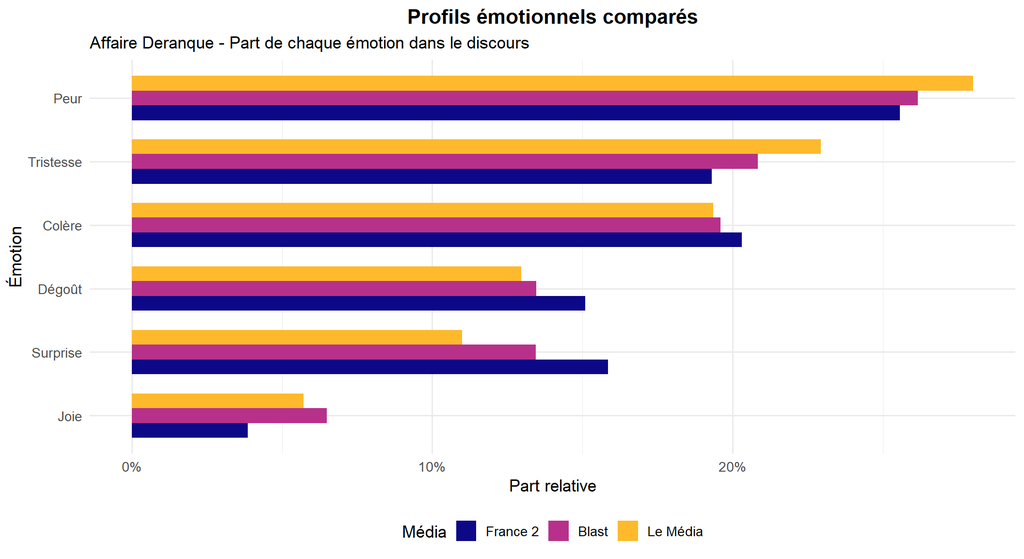

```r
# Proportion de chaque émotion dans le discours de chaque média
emotion_labels <- c(
  joy = "Joie", fear = "Peur", sadness = "Tristesse",
  anger = "Colère", surprise = "Surprise", disgust = "Dégoût"
)

emotion_global <- tokens_seq1 |>
  pivot_longer(joy:disgust, names_to = "emotion", values_to = "score") |>
  filter(score == 1) |>
  group_by(source, emotion) |>
  summarise(count = n(), .groups = "drop") |>
  group_by(source) |>
  mutate(prop = count / sum(count)) |>
  ungroup() |>
  mutate(emotion_fr = recode(emotion, !!!emotion_labels))

ggplot(emotion_global,
       aes(x = reorder(emotion_fr, prop), y = prop, fill = source)) +
  geom_bar(stat = "identity", position = "dodge", width = 0.7) +
  coord_flip() +
  scale_fill_viridis_d(option = "plasma", end = 0.85) +
  scale_y_continuous(labels = percent_format(accuracy = 1)) +
  theme_minimal(base_size = 13) +
  theme(plot.title = element_text(face = "bold", hjust = 0.5),
        legend.position = "bottom") +
  labs(
    title    = "Profils émotionnels comparés",
    subtitle = paste(SEQ1_NOM, "- Part de chaque émotion dans le discours"),
    y = "Part relative", x = "Émotion", fill = "Média"
  )
```

## 6.3 Polarité : positif / négatif

[figure not shown]

```r
polarity_doc <- tokens_seq1 |>
  count(source, id, polarity) |>
  group_by(source, id) |>
  mutate(prop = n / sum(n)) |>
  ungroup()

polarity_summary <- polarity_doc |>
  group_by(source, polarity) |>
  summarise(prop_moy = mean(prop), .groups = "drop")

ggplot(polarity_summary,
       aes(x = source, y = prop_moy, fill = polarity)) +
  geom_bar(stat = "identity", position = "fill", width = 0.6) +
  scale_fill_manual(values = c("positive" = "#4a9e6b", "negative" = "#c0392b"),
                    labels = c("Positif", "Négatif")) +
  scale_y_continuous(labels = percent_format()) +
  theme_minimal(base_size = 13) +
  theme(plot.title = element_text(face = "bold", hjust = 0.5),
        legend.position = "bottom") +
  labs(
    title    = "Répartition positif / négatif",
    subtitle = SEQ1_NOM,
    y = "Proportion", x = "", fill = "Polarité"
  )
```

## 6.4 Nuage de mots émotionnels

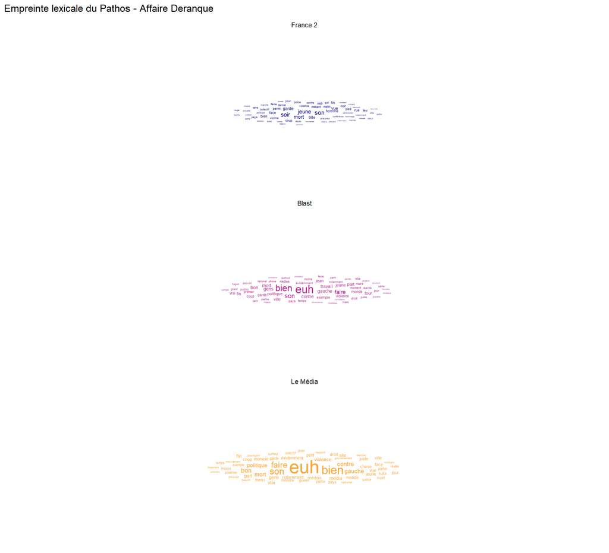

```r
top_emot <- tokens_seq1 |>
  count(source, word, sort = TRUE) |>
  group_by(source) |>
  slice_max(n, n = 60) |>
  ungroup()

ggplot(top_emot, aes(label = word, size = n, color = source)) +
  geom_text_wordcloud_area(rm_outside = TRUE) +
  facet_wrap(~source, ncol = 1) +
  scale_size_area(max_size = 14) +
  scale_color_viridis_d(option = "plasma", end = 0.8) +
  theme_minimal() +
  labs(title = paste("Empreinte lexicale du Pathos -", SEQ1_NOM))
```

# 7 Analyse du Logos - Rationalité argumentative

## 7.1 Connecteurs logiques et densité de chiffres

```
## $`1`
```

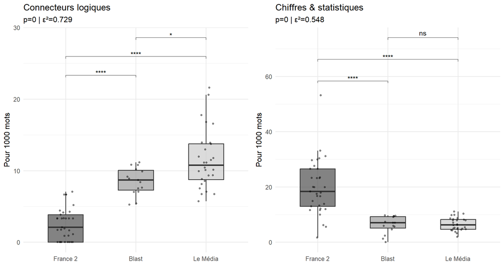

```
##
## $`2`
```

[figure not shown]

```
##
## attr(,"class")
## [1] "list"      "ggarrange"
```

```r
# Dictionnaires
connecteurs_uni <- c(
  "car", "donc", "ainsi", "alors", "pourtant", "néanmoins",
  "toutefois", "cependant", "revanche", "conséquent", "effectivement"
)
connecteurs_bi <- c(
  "parce que", "puisque", "c'est pourquoi", "en effet",
  "par conséquent", "dès lors", "c'est ainsi", "en revanche"
)

logos_seq1 <- corpus_seq1 |>
  mutate(
    txt_lc = str_to_lower(text_seq),

    # Unigrams (word boundary)
    conn_uni = str_count(
      txt_lc,
      paste0("\\b(", paste(connecteurs_uni, collapse = "|"), ")\\b")
    ),
    # Bigrams (fixed string)
    conn_bi  = rowSums(sapply(connecteurs_bi,
                              function(b) str_count(txt_lc, fixed(b)))),

    conn_total  = conn_uni + conn_bi,
    conn_dens   = conn_total  / word_count_seq * 1000,

    # Chiffres et pourcentages (excluant chaines, heures et dates)
    stat_count  = map_dbl(text_seq, count_logos_stats),
    stat_dens   = stat_count / word_count_seq * 1000
  )

# Tests
kw_conn <- logos_seq1 |> kruskal_test(conn_dens ~ source)
pw_conn <- logos_seq1 |>
  wilcox_test(conn_dens ~ source, p.adjust.method = "bonferroni") |>
  add_significance() |> add_xy_position(x = "source")
es_conn <- logos_seq1 |> kruskal_effsize(conn_dens ~ source)

kw_stat <- logos_seq1 |> kruskal_test(stat_dens ~ source)
pw_stat <- logos_seq1 |>
  wilcox_test(stat_dens ~ source, p.adjust.method = "bonferroni") |>
  add_significance() |> add_xy_position(x = "source")
es_stat <- logos_seq1 |> kruskal_effsize(stat_dens ~ source)

# Graphiques
p_conn <- ggplot(logos_seq1, aes(x = source, y = conn_dens, fill = source)) +
  geom_boxplot(alpha = 0.7, outlier.shape = NA, width = 0.5) +
  geom_jitter(width = 0.12, alpha = 0.4, size = 1) +
  stat_pvalue_manual(pw_conn, label = "p.adj.signif", tip.length = 0.01) +
  scale_fill_grey(start = 0.3, end = 0.8) +
  theme_minimal(base_size = 12) + theme(legend.position = "none") +
  labs(title = "Connecteurs logiques",
       subtitle = paste0("p=", round(kw_conn$p, 4),
                         " | ε²=", round(es_conn$effsize, 3)),
       y = "Pour 1000 mots", x = "")

p_stat <- ggplot(logos_seq1, aes(x = source, y = stat_dens, fill = source)) +
  geom_boxplot(alpha = 0.7, outlier.shape = NA, width = 0.5) +
  geom_jitter(width = 0.12, alpha = 0.4, size = 1) +
  stat_pvalue_manual(pw_stat, label = "p.adj.signif", tip.length = 0.01) +
  scale_fill_grey(start = 0.3, end = 0.8) +
  theme_minimal(base_size = 12) + theme(legend.position = "none") +
  labs(title = "Chiffres & statistiques",
       subtitle = paste0("p=", round(kw_stat$p, 4),
                         " | ε²=", round(es_stat$effsize, 3)),
       y = "Pour 1000 mots", x = "")

ggarrange(p_conn, p_stat, ncol = 2,
          top = text_grob("Rationalité argumentative (Logos)", face = "bold"))
```

# 8 Analyse du Cadrage - Champs lexicaux

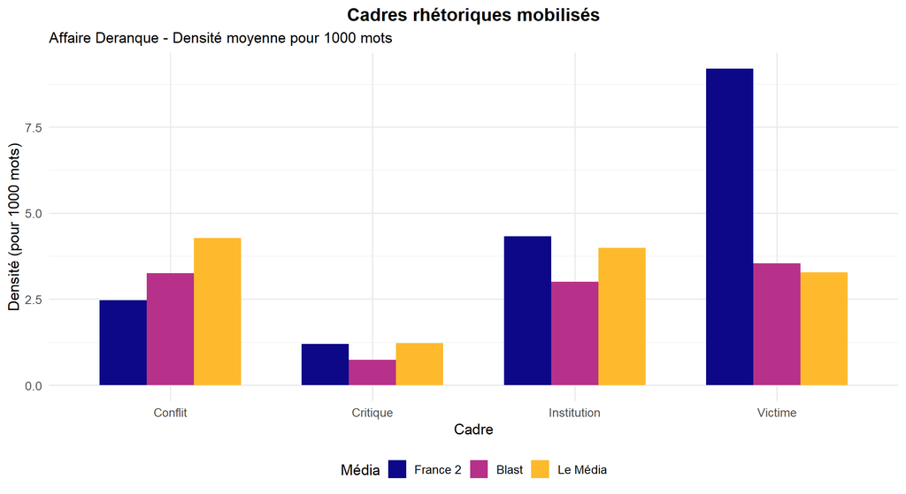

```r
# ─── Dictionnaires de cadrage ─────────────────────────────────────────────
# → À affiner selon les résultats préliminaires et la réalité de l'affaire

cadres <- list(

  # Cadre "Conflit / Guerre" - dramatisation, polarisation Eux/Nous
  Conflit = c(
    "combat", "guerre", "lutte", "bataille", "ennemi", "affrontement",
    "attaque", "violence", "résistance", "offensive", "choc", "tension",
    "crise", "rupture", "conflit", "danger"
  ),

  # Cadre "Institution / Pouvoir" - légitimation des sources officielles
  Institution = c(
    "gouvernement", "ministre", "état", "autorité", "préfet", "police",
    "justice", "tribunal", "armée", "gendarmerie", "parquet", "officiel",
    "institution", "administration", "rapport", "communiqué"
  ),

  # Cadre "Victime / Humanisation" - pathos, proximité émotionnelle
  Victime = c(
    "famille", "proche", "victime", "souffrance", "deuil", "drame",
    "tragédie", "enfant", "jeune", "mort", "décès", "perte", "traumatisme",
    "témoignage", "témoigne", "émotion", "soutien"
  ),

  # Cadre "Critique / Mise en cause" - propre aux médias alternatifs
  Critique = c(
    "scandale", "honte", "inacceptable", "inadmissible", "dénonce",
    "condamne", "responsable", "coupable", "impunité", "justice",
    "réclame", "exige", "colère", "indignation", "révolte", "mobilise"
  )
)

# ─── Calcul ───────────────────────────────────────────────────────────────
count_cadre <- function(text, terms) {
  sum(str_count(str_to_lower(text),
                paste0("\\b(", paste(terms, collapse = "|"), ")\\b")))
}

cadrage_seq1 <- corpus_seq1 |>
  mutate(
    Conflit     = map_dbl(text_seq, ~ count_cadre(.x, cadres$Conflit)),
    Institution = map_dbl(text_seq, ~ count_cadre(.x, cadres$Institution)),
    Victime     = map_dbl(text_seq, ~ count_cadre(.x, cadres$Victime)),
    Critique    = map_dbl(text_seq, ~ count_cadre(.x, cadres$Critique)),
    across(Conflit:Critique, ~ .x / word_count_seq * 1000,
           .names = "dens_{.col}")
  )

cadrage_long <- cadrage_seq1 |>
  select(id, source, starts_with("dens_")) |>
  pivot_longer(starts_with("dens_"), names_to = "Cadre", values_to = "Densité") |>
  mutate(Cadre = str_remove(Cadre, "dens_"))

cadrage_summary <- cadrage_long |>
  group_by(source, Cadre) |>
  summarise(moy = mean(Densité, na.rm = TRUE), .groups = "drop")

ggplot(cadrage_summary, aes(x = Cadre, y = moy, fill = source)) +
  geom_bar(stat = "identity", position = "dodge", width = 0.7) +
  scale_fill_viridis_d(option = "plasma", end = 0.85) +
  theme_minimal(base_size = 13) +
  theme(plot.title = element_text(face = "bold", hjust = 0.5),
        legend.position = "bottom") +
  labs(
    title    = "Cadres rhétoriques mobilisés",
    subtitle = paste(SEQ1_NOM, "- Densité moyenne pour 1000 mots"),
    y = "Densité (pour 1000 mots)", x = "Cadre", fill = "Média"
  )
```

```r
# ─── Test statistique sur le cadre le plus discriminant ───────────────────
# (à répéter pour chaque cadre selon les résultats visuels)
kw_cadre <- cadrage_seq1 |> kruskal_test(dens_Critique ~ source)
pw_cadre <- cadrage_seq1 |>
  wilcox_test(dens_Critique ~ source, p.adjust.method = "bonferroni") |>
  add_significance()
es_cadre <- cadrage_seq1 |> kruskal_effsize(dens_Critique ~ source)

cat("=== Cadre 'Critique' - Kruskal-Wallis ===\n")
```

```
## === Cadre 'Critique' - Kruskal-Wallis ===
```

```r
print(kw_cadre)
```

```
## # A tibble: 1 × 6
##   .y.               n statistic    df      p method
## * <chr>         <int>     <dbl> <int>  <dbl> <chr>
## 1 dens_Critique    76      6.06     2 0.0483 Kruskal-Wallis
```

```r
cat("\n=== Pairwise Wilcoxon ===\n")
```

```
##
## === Pairwise Wilcoxon ===
```

```r
print(pw_cadre)
```

```
## # A tibble: 3 × 9
##   .y.           group1   group2      n1    n2 statistic     p p.adj p.adj.signif
##   <chr>         <chr>    <chr>    <int> <int>     <dbl> <dbl> <dbl> <chr>
## 1 dens_Critique France 2 Blast       33    15       197 0.242 0.726 ns
## 2 dens_Critique France 2 Le Média    33    28       314 0.029 0.086 ns
## 3 dens_Critique Blast    Le Média    15    28       143 0.09  0.27  ns
```

```r
cat("\n=== Taille d'effet ε² ===\n")
```

```
##
## === Taille d'effet ε² ===
```

```r
print(es_cadre)
```

```
## # A tibble: 1 × 5
##   .y.               n effsize method  magnitude
## * <chr>         <int>   <dbl> <chr>   <ord>
## 1 dens_Critique    76  0.0556 eta2[H] small
```

# 9 Analyse de la diversité des sources

> Les médias alternatifs revendiquent (Cardon & Granjon) une rigueur journalistique accrue. L’une de ses manifestations serait une diversité de sources plus grande. On l’opérationnalise via deux proxies textuels : **(1) les verbes de citation** et **(2) la distinction sources institutionnelles vs individuelles.**

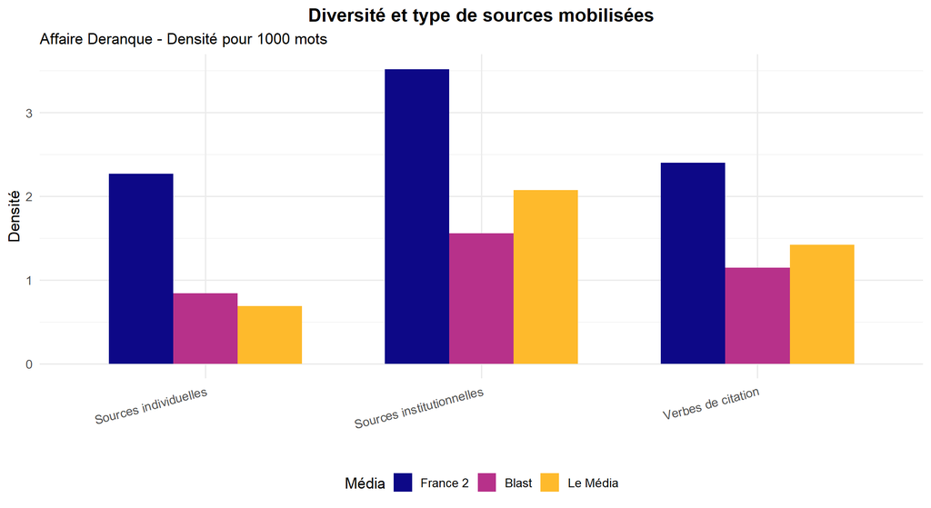

```r
# Verbes de citation

verbes_citation <- c(
  "selon", "affirme", "déclare", "indique", "précise", "rapporte",
  "témoigne", "explique", "souligne", "estime", "ajoute", "révèle",
  "confirme", "dément", "assure", "reconnaît", "admet"
)

# Sources institutionnelles vs individuelles
sources_instit <- c(
  "gouvernement", "ministère", "préfecture", "parquet", "police",
  "gendarmerie", "armée", "élysée", "matignon", "commission", "rapport", "Président"
)

sources_indiv <- c(
  "famille", "proche", "ami", "collègue", "témoin", "habitant",
  "citoyen", "manifestant", "victime", "survivant"
)

sources_seq1 <- corpus_seq1 |>
  mutate(
    txt_lc    = str_to_lower(text_seq),
    cit_count = str_count(
      txt_lc,
      paste0("\\b(", paste(verbes_citation, collapse = "|"), ")\\b")
    ),
    cit_dens  = cit_count / word_count_seq * 1000,

    instit_count = str_count(
      txt_lc,
      paste0("\\b(", paste(sources_instit, collapse = "|"), ")\\b")
    ),
    instit_dens  = instit_count / word_count_seq * 1000,

    indiv_count  = str_count(
      txt_lc,
      paste0("\\b(", paste(sources_indiv, collapse = "|"), ")\\b")
    ),
    indiv_dens   = indiv_count / word_count_seq * 1000,

    # Ratio instituionnel/individuel (>1 = dominance institutionnelle)
    ratio_instit = ifelse(indiv_count > 0,
                          instit_count / indiv_count, NA_real_)
  )

# ─── Visualisation ───────────────────────────────────────────────────────
sources_long <- sources_seq1 |>
  select(id, source, cit_dens, instit_dens, indiv_dens) |>
  pivot_longer(c(cit_dens, instit_dens, indiv_dens),
               names_to = "Indicateur", values_to = "Densité") |>
  mutate(Indicateur = recode(Indicateur,
    cit_dens    = "Verbes de citation",
    instit_dens = "Sources institutionnelles",
    indiv_dens  = "Sources individuelles"
  ))

sources_long |>
  group_by(source, Indicateur) |>
  summarise(moy = mean(Densité, na.rm = TRUE), .groups = "drop") |>
  ggplot(aes(x = Indicateur, y = moy, fill = source)) +
  geom_bar(stat = "identity", position = "dodge", width = 0.7) +
  scale_fill_viridis_d(option = "plasma", end = 0.85) +
  theme_minimal(base_size = 13) +
  theme(plot.title = element_text(face = "bold", hjust = 0.5),
        legend.position = "bottom",
        axis.text.x = element_text(angle = 15, hjust = 1)) +
  labs(
    title    = "Diversité et type de sources mobilisées",
    subtitle = paste(SEQ1_NOM, "- Densité pour 1000 mots"),
    y = "Densité", x = "", fill = "Média"
  )
```

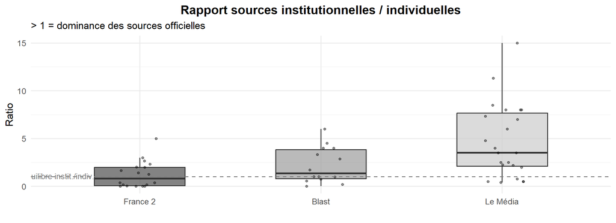

```r
# ─── Ratio sources institutionnelles / individuelles ──────────────────────
# Un ratio élevé = recours aux sources officielles privilégié
# (attendu : plus élevé pour France 2 selon la critique contre-hégémonique)
sources_seq1 |>
  filter(!is.na(ratio_instit)) |>
  ggplot(aes(x = source, y = ratio_instit, fill = source)) +
  geom_boxplot(alpha = 0.7, outlier.shape = NA, width = 0.5) +
  geom_jitter(width = 0.12, alpha = 0.4, size = 1.2) +
  geom_hline(yintercept = 1, linetype = "dashed", color = "grey50") +
  annotate("text", x = 0.55, y = 1.08, label = "Équilibre instit./indiv.",
           size = 3.5, color = "grey50") +
  scale_fill_grey(start = 0.3, end = 0.8) +
  theme_minimal(base_size = 13) +
  theme(legend.position = "none",
        plot.title = element_text(face = "bold", hjust = 0.5)) +
  labs(
    title    = "Rapport sources institutionnelles / individuelles",
    subtitle = "> 1 = dominance des sources officielles",
    y = "Ratio", x = ""
  )
```

# 10 Analyse de la réactivité temporelle

> La réactivité éditoriale (à quel moment et avec quelle intensité un média couvre un événement) est un indicateur du rôle de **gatewatcher** vs **gatekeeper** (Neveu). Les médias alternatifs répondent-ils plus vite ou plus durablement ?

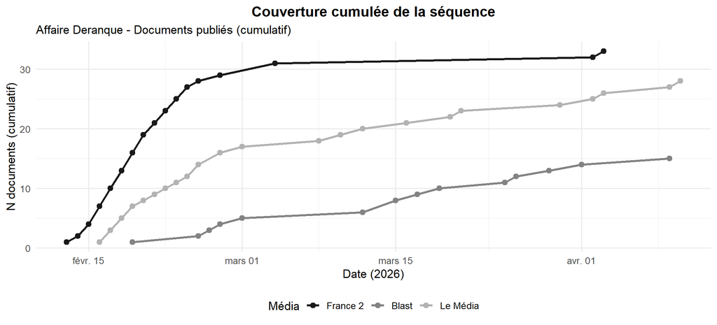

```r
# ─── Couverture cumulée dans le temps ────────────────────────────────────
reactivity <- corpus_seq1 |>
  count(source, date) |>
  group_by(source) |>
  arrange(date) |>
  mutate(cumul = cumsum(n)) |>
  ungroup()

ggplot(reactivity, aes(x = date, y = cumul,
                        color = source, group = source)) +
  geom_line(linewidth = 1.2) +
  geom_point(size = 2.5) +
  scale_color_grey(start = 0.1, end = 0.7) +
  theme_minimal(base_size = 13) +
  theme(plot.title = element_text(face = "bold", hjust = 0.5),
        legend.position = "bottom") +
  labs(
    title    = "Couverture cumulée de la séquence",
    subtitle = paste(SEQ1_NOM, "- Documents publiés (cumulatif)"),
    x = "Date (2026)", y = "N documents (cumulatif)", color = "Média"
  )
```

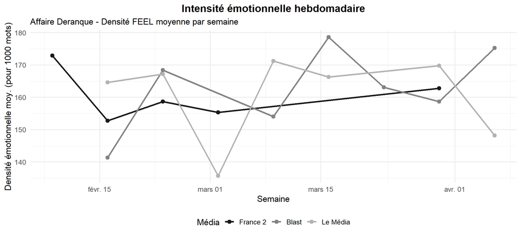

```r
# ─── Densité émotionnelle hebdomadaire ─────────────────────────────────
# Permet de voir si l'intensité émotionnelle varie dans le temps
# (couverture "à chaud" vs "refroidissement" éditorial)
weekly_emot <- intensity_seq1 |>
  mutate(semaine = floor_date(date, "week", week_start = 1)) |>
  group_by(source, semaine) |>
  summarise(emot_moy = mean(emot_density, na.rm = TRUE), .groups = "drop")

ggplot(weekly_emot,
       aes(x = semaine, y = emot_moy, color = source, group = source)) +
  geom_line(linewidth = 1.1) +
  geom_point(size = 2.5) +
  scale_color_grey(start = 0.1, end = 0.7) +
  theme_minimal(base_size = 13) +
  theme(plot.title = element_text(face = "bold", hjust = 0.5),
        legend.position = "bottom") +
  labs(
    title    = "Intensité émotionnelle hebdomadaire",
    subtitle = paste(SEQ1_NOM, "- Densité FEEL moyenne par semaine"),
    x = "Semaine", y = "Densité émotionnelle moy. (pour 1000 mots)",
    color = "Média"
  )
```

# 11 ACP - Structure différentielle des médias

> L’ACP projette les médias dans un espace factoriel construit à partir de l’ensemble des indicateurs calculés. Elle répond à la question : **les profils rhétoriques sont-ils suffisamment différenciés pour distinguer les médias dans un espace multidimensionnel ?**

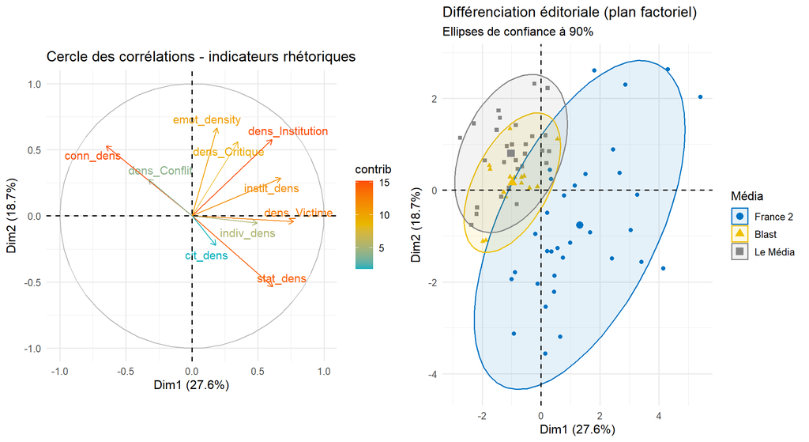

```r
# Matrice d'indicateurs par document
acp_input <- intensity_seq1 |>
  select(id, source, emot_density) |>
  left_join(logos_seq1 |> select(id, conn_dens, stat_dens), by = "id") |>
  left_join(cadrage_seq1 |>
              select(id, dens_Conflit, dens_Institution, dens_Victime,
                     dens_Critique), by = "id") |>
  left_join(sources_seq1 |> select(id, cit_dens, instit_dens, indiv_dens),
            by = "id") |>
  drop_na()

acp_matrix <- acp_input |>
  select(-id, -source) |>
  # Suppression des colonnes à variance nulle
  select(where(~ var(.x) > 0))

# Vérification du nombre minimal d'individus
if (nrow(acp_matrix) >= 5) {

  res_pca <- PCA(acp_matrix, graph = FALSE, scale.unit = TRUE)

  # Cercle des corrélations
  p_var <- fviz_pca_var(res_pca,
               col.var       = "contrib",
               gradient.cols = c("#00AFBB", "#E7B800", "#FC4E07"),
               repel         = TRUE) +
    theme_minimal(base_size = 12) +
    labs(title = "Cercle des corrélations - indicateurs rhétoriques")

  # Projection des médias
  p_ind <- fviz_pca_ind(res_pca,
               geom.ind      = "point",
               col.ind       = acp_input$source,
               palette       = "jco",
               addEllipses   = TRUE,
               ellipse.level = 0.90,
               legend.title  = "Média") +
    theme_minimal(base_size = 12) +
    labs(title = "Différenciation éditoriale (plan factoriel)",
         subtitle = "Ellipses de confiance à 90%")

  print(ggarrange(p_var, p_ind, ncol = 2))

} else {
  message("Pas assez de documents pour une ACP fiable. ",
          "Augmente le corpus ou réduis la sélection thématique.")
}
```

# 12 Tableau de synthèse des résultats statistiques

```r
synthesis <- tibble(
  Dimension    = c("Pathos", "Logos", "Logos",
                   "Cadrage", "Sources"),
  Indicateur   = c(
    "Densité émotionnelle (FEEL)",
    "Connecteurs logiques",
    "Chiffres & statistiques",
    "Cadre 'Critique'",
    "Verbes de citation"
  ),
  KW_p         = c(
    round(kw_emot$p, 4), round(kw_conn$p, 4), round(kw_stat$p, 4),
    round(kw_cadre$p, 4), NA_real_
  ),
  Effet_eps2   = c(
    round(es_emot$effsize, 3), round(es_conn$effsize, 3),
    round(es_stat$effsize, 3), round(es_cadre$effsize, 3), NA_real_
  ),
  Interprétation = c(
    "Blast/Le Média > France 2 ? (hypothèse pathos)",
    "France 2 > alternatifs ? (hypothèse logos)",
    "Le Parisien-type : logos vs pathos",
    "Blast/Le Média > France 2 ? (critique contre-hégémonique)",
    "À calculer selon résultats"
  )
)

synthesis |>
  kable(
    caption   = paste("Synthèse statistique -", SEQ1_NOM,
                      "(α = 0,05 | correction Bonferroni sur pairwise)"),
    col.names = c("Dimension", "Indicateur", "p (KW)", "ε²", "Interprétation attendue"),
    format.args = list(big.mark = " ")
  ) |>
  kable_styling(
    bootstrap_options = c("striped", "hover", "condensed"),
    full_width = FALSE
  ) |>
  column_spec(3, bold = TRUE,
              color = ifelse(is.na(synthesis$KW_p), "grey",
                             ifelse(synthesis$KW_p < 0.05, "#27ae60", "#c0392b")))
```

Synthèse statistique - Affaire Deranque (α = 0,05 | correction Bonferroni sur pairwise)

| Dimension | Indicateur | p (KW) | ε² | Interprétation attendue |
| --- | --- | --- | --- | --- |
| Pathos | Densité émotionnelle (FEEL) | 0.2660 | 0.009 | Blast/Le Média > France 2 ? (hypothèse pathos) |
| Logos | Connecteurs logiques | 0.0000 | 0.729 | France 2 > alternatifs ? (hypothèse logos) |
| Logos | Chiffres & statistiques | 0.0000 | 0.548 | Le Parisien-type : logos vs pathos |
| Cadrage | Cadre ‘Critique’ | 0.0483 | 0.056 | Blast/Le Média > France 2 ? (critique contre-hégémonique) |
| Sources | Verbes de citation | NA | NA | À calculer selon résultats |

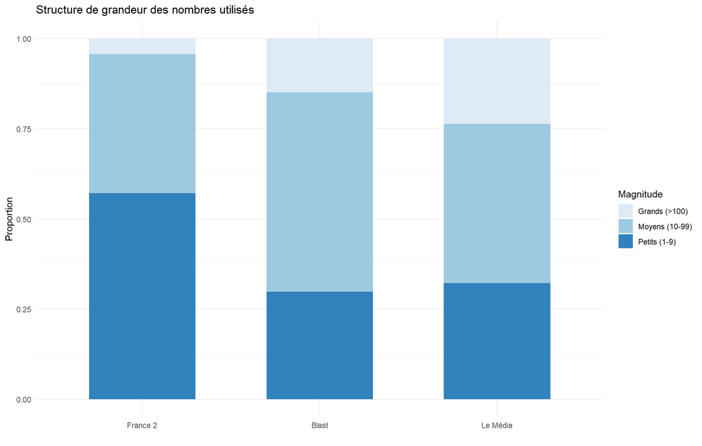

```r
# ─── 1. Préparation du dictionnaire ──────────────────────────────────────────
# On nettoie le dictionnaire pour éviter les doublons ou les cases vides
feel_clean <- feel |>
  filter(!is.na(word)) |>
  distinct(word, .keep_all = TRUE)

# ─── 2. Calcul des indicateurs par Tokenisation ──────────────────────────────
# Cette méthode est 10x plus rapide que la regex pour les gros corpus

# Étape A : On compte les émotions (Pathos) sur le texte EXTRAIT
pathos_counts <- corpus_seq1 |>
  unnest_tokens(word, text_seq) |>
  inner_join(feel_clean, by = "word") |>
  count(id, name = "emot_count")

# Étape B : On assemble tout dans le corpus global (version thématique)
corpus_global_stats <- corpus_seq1 |>
  left_join(pathos_counts, by = "id") |>
  mutate(
    emot_count = replace_na(emot_count, 0),
    emot_dens  = (emot_count / word_count_seq) * 1000,

    # Pour les connecteurs (Logos), on peut garder la regex car la liste est courte
    txt_lc = str_to_lower(text_seq),
    conn_pattern = paste0("\\b(", paste(c(connecteurs_uni, connecteurs_bi), collapse = "|"), ")\\b"),
    conn_count = str_count(txt_lc, conn_pattern),
    conn_dens  = (conn_count / word_count_seq) * 1000,

    # Chiffres (Nettoyés des noms de chaines, heures et dates)
    stat_count = map_dbl(text_seq, count_logos_stats),
    stat_dens  = (stat_count / word_count_seq) * 1000,

    # Sources (Ethos)
    cit_pattern = paste0("\\b(", paste(verbes_citation, collapse = "|"), ")\\b"),
    cit_count  = str_count(txt_lc, cit_pattern),
    cit_dens   = (cit_count / word_count_seq) * 1000
  )

# ─── 2.1 Analyse par magnitude (Bloc supplémentaire) ─────────────────────────
# On regarde si les médias utilisent plutôt des petits ou gros chiffres
mag_stats <- corpus_seq1 |>
  unnest_tokens(nombre, text_seq) |>
  filter(str_detect(nombre, "^\\d+$")) |>
  mutate(nombre = as.numeric(nombre)) |>
  # On exclut les années et les heures potentielles par sécurité ici aussi
  filter(!nombre %in% 1900:2099, nombre < 1000000) |>
  mutate(grandeur = case_when(
    nombre < 10   ~ "Petits (1-9)",
    nombre < 100  ~ "Moyens (10-99)",
    TRUE          ~ "Grands (>100)"
  )) |>
  count(source, grandeur) |>
  group_by(source) |>
  mutate(prop = n / sum(n)) |>
  ungroup()

# Visualisation rapide de la structure des nombres
ggplot(mag_stats, aes(x = source, y = prop, fill = grandeur)) +
  geom_bar(stat = "identity", position = "fill", width = 0.6) +
  scale_fill_brewer(palette = "Blues") +
  theme_minimal() +
  labs(title = "Structure de grandeur des nombres utilisés",
       y = "Proportion", x = "", fill = "Magnitude")
```

[figure not shown]

```r
# ─── 3. Synthèse des "Tempéraments Médiatiques" ──────────────────────────────
global_summary <- corpus_global_stats |>
  group_by(source) |>
  summarise(
    Across_Pathos = mean(emot_dens, na.rm = TRUE),
    Across_Logos  = mean(conn_dens, na.rm = TRUE),
    Across_Stats  = mean(stat_dens, na.rm = TRUE),
    Across_Cit    = mean(cit_dens, na.rm = TRUE),
    .groups = "drop"
  ) |>
  pivot_longer(-source, names_to = "Dimension", values_to = "Valeur")

# ─── 4. Visualisation ────────────────────────────────────────────────────────
ggplot(global_summary, aes(x = Dimension, y = Valeur, fill = source)) +
  geom_bar(stat = "identity", position = "dodge", width = 0.7) +
  facet_wrap(~Dimension, scales = "free", ncol = 2) +
  scale_fill_viridis_d(option = "mako", begin = 0.2, end = 0.8) +
  theme_minimal(base_size = 13) +
  theme(legend.position = "bottom",
        axis.text.x = element_blank(),
        plot.title = element_text(face = "bold")) +
  labs(
    title = "Profils rhétoriques moyens (ADN des médias)",
    subtitle = "Moyennes calculées sur l'intégralité du corpus (2026)",
    y = "Densité moyenne (pour 1000 mots)", x = "", fill = "Média"
  )
```